# BIOL606_hw15_Shah.rmd

Priyanshi Shah

2023-04-17

Visualize the data distribution for each compound. Should you log transform the data?

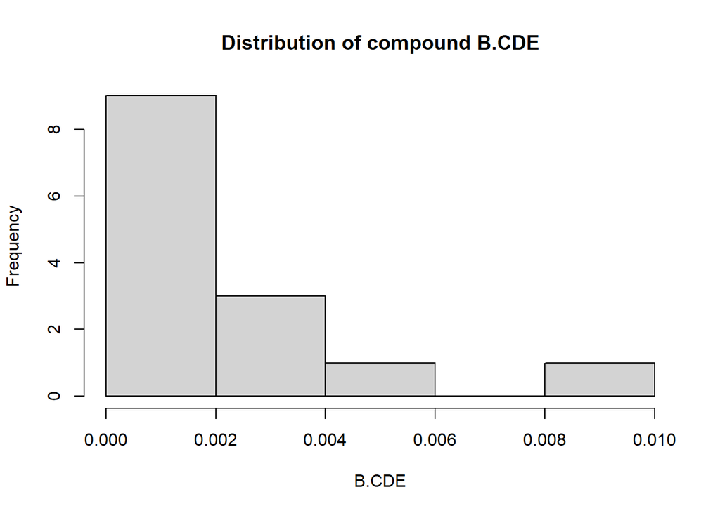

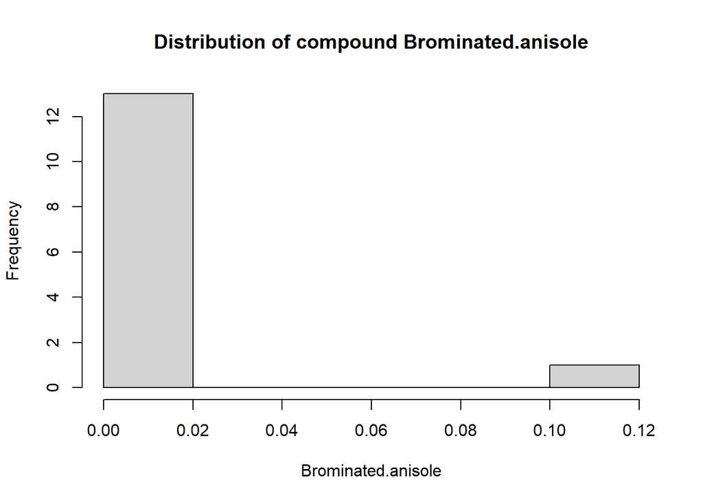

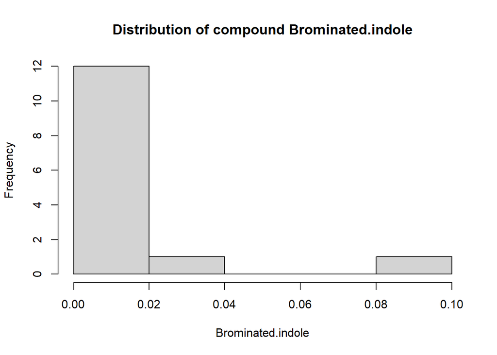

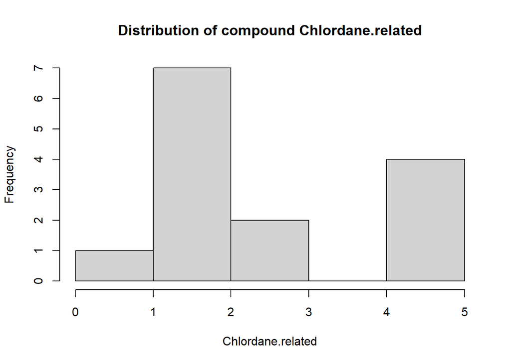

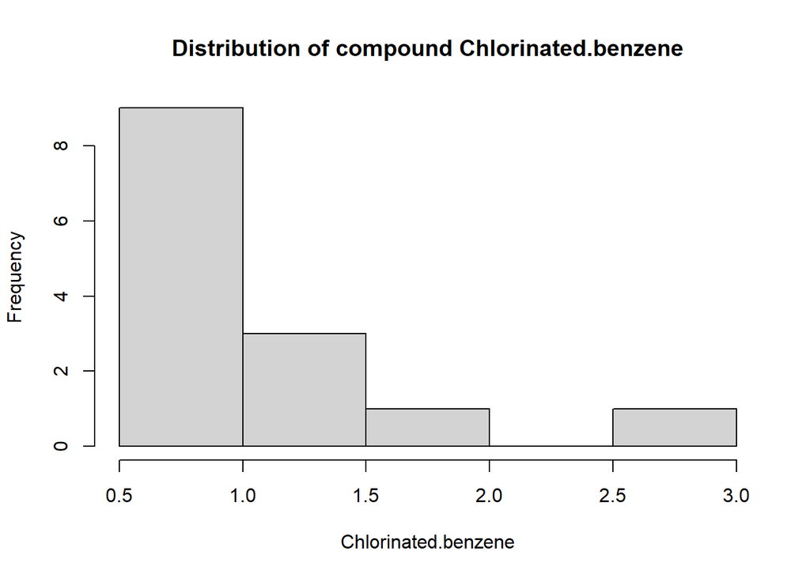

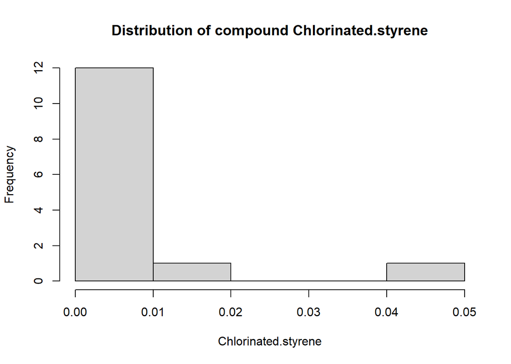

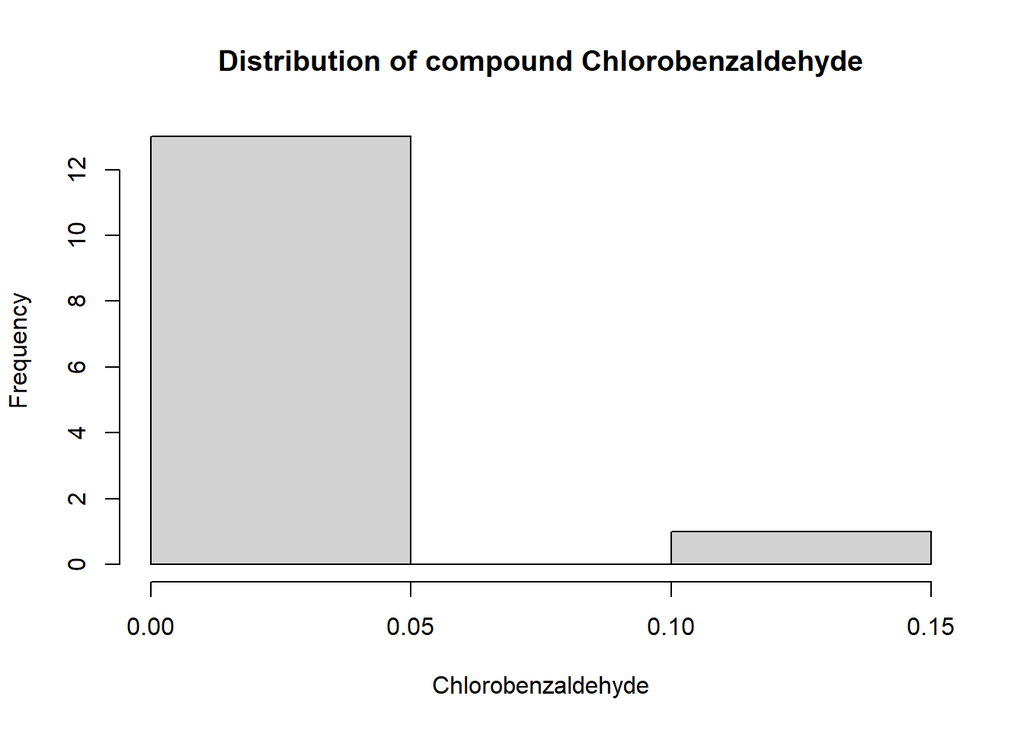

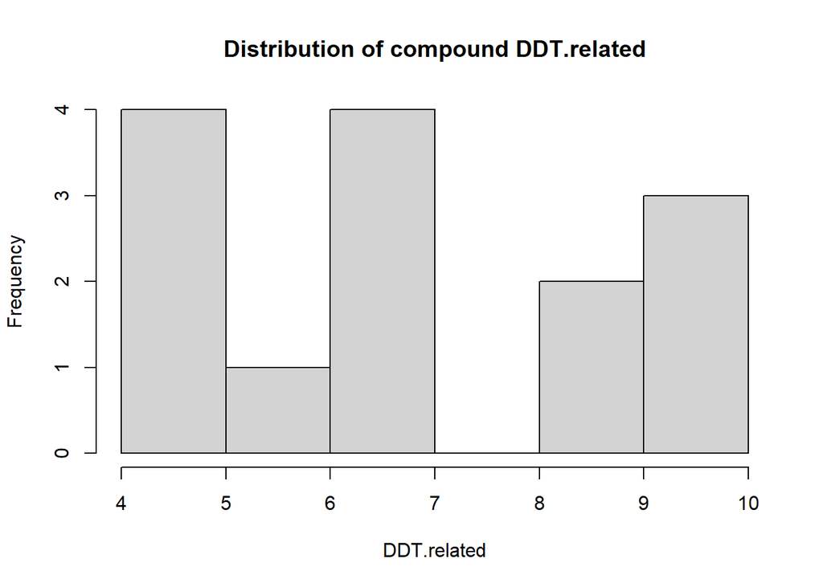

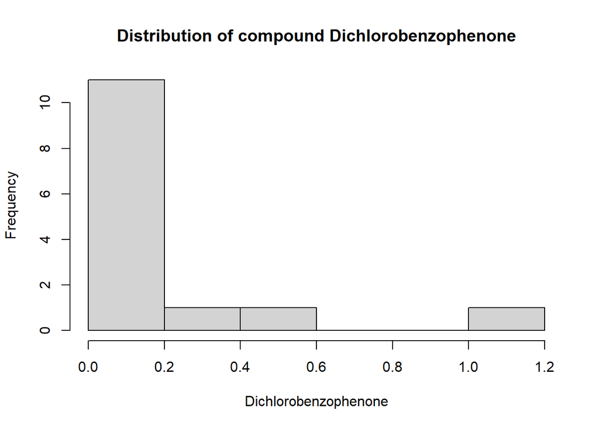

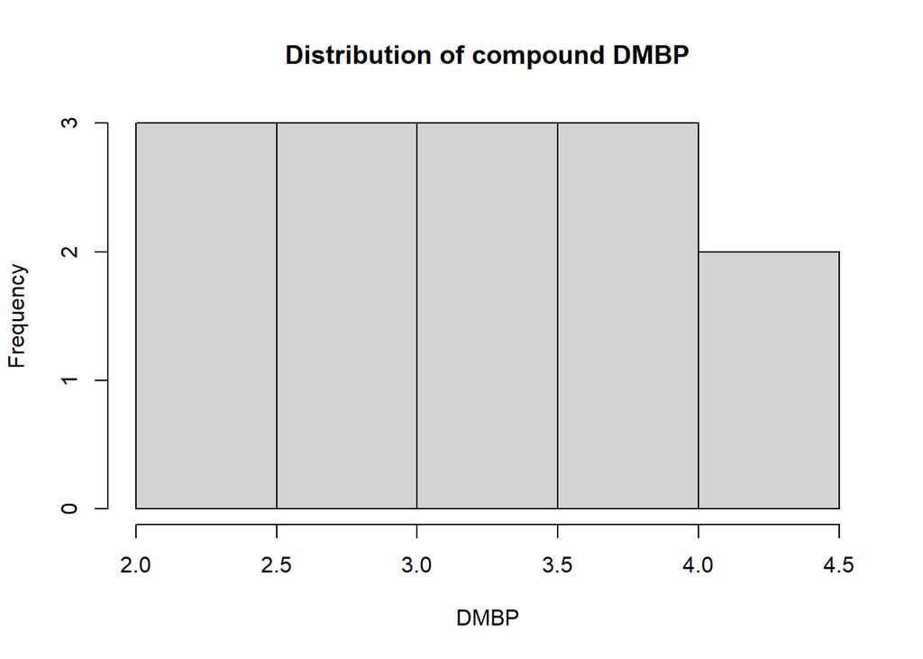

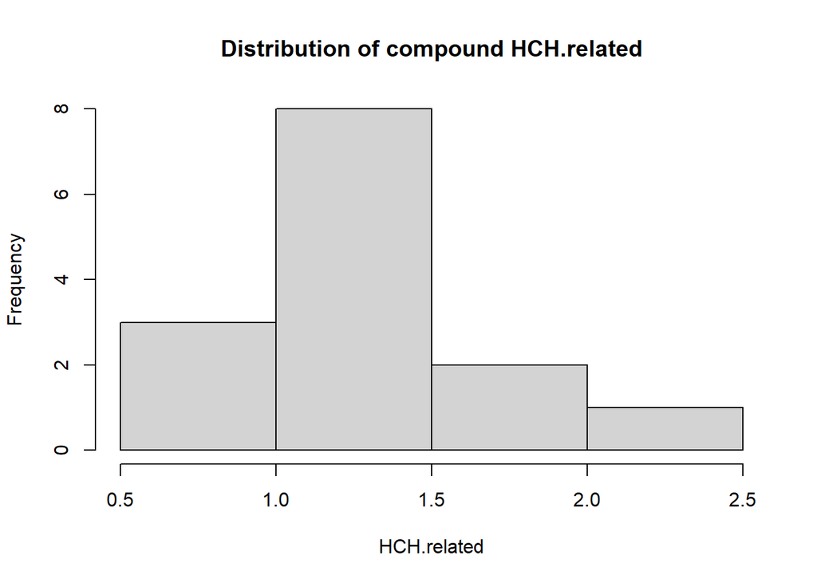

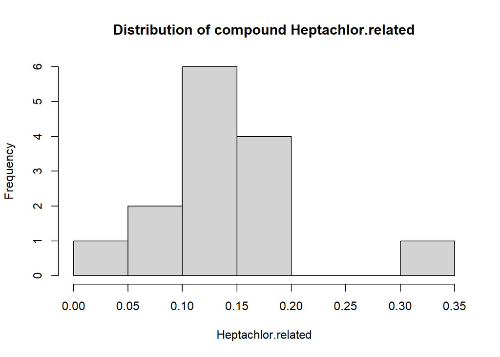

[21 more figures not shown]

```r
#loading the data
dolphin <- read.csv("Trego2018.csv", header = TRUE)
#View(dolphin) #Yup, Perfect


#histogram of distribution for each variable
for(col in names(dolphin[3:35])){
  hist(dolphin[[col]], xlab=col,main = paste("Distribution of compound" , col))
}
```

```r
#I believe log-transformation is needed. so
#cols_to_transform <- c(3:35)

#dolphin[cols_to_transform] <- apply(dolphin[cols_to_transform], 2, log)

#write.csv(dolphin, "dolphin_log_transformed.csv", row.names = FALSE)
```

Perform a PCA (i.e. PCoA using Euclidean distance)

```r
#leaving the first and second columns out because Columns 1 & 2 list ID and maturity (immature or mature)
#Columns 3:35 list relative abundance of each halogenated organic compound

#dolphin_log_transformed <- read.csv("dolphin_log_transformed.csv", header = TRUE)

dolphin.pca=prcomp(dolphin[,c(-1,-2)], center=TRUE, scale.= TRUE)# initial PCoA minus the first 2 columns
summary(dolphin.pca)
```

```
## Importance of components:
##                           PC1    PC2     PC3     PC4    PC5     PC6     PC7
## Standard deviation     3.8291 2.2440 1.61805 1.57766 1.4668 1.28541 1.20702
## Proportion of Variance 0.4443 0.1526 0.07934 0.07542 0.0652 0.05007 0.04415
## Cumulative Proportion  0.4443 0.5969 0.67624 0.75166 0.8169 0.86693 0.91107
##                            PC8     PC9    PC10    PC11    PC12    PC13
## Standard deviation     0.92830 0.88190 0.73948 0.62827 0.49040 0.33614
## Proportion of Variance 0.02611 0.02357 0.01657 0.01196 0.00729 0.00342
## Cumulative Proportion  0.93719 0.96076 0.97733 0.98929 0.99658 1.00000
##                             PC14
## Standard deviation     5.116e-16
## Proportion of Variance 0.000e+00
## Cumulative Proportion  1.000e+00
```

Show the relationship between the dolphins and the compounds using a biplot

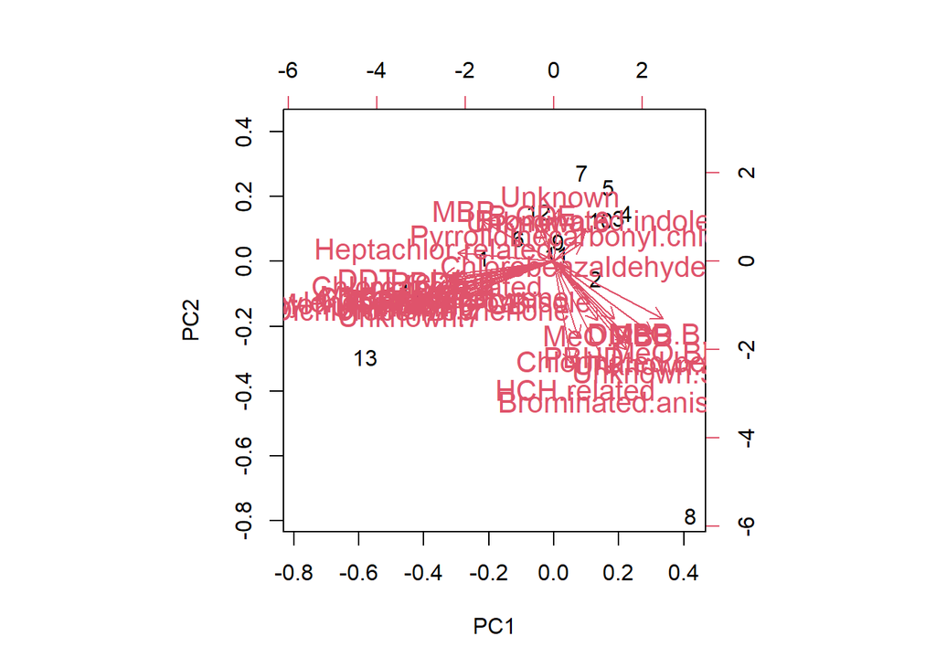

```r
#There are total 33 variables so expect a lot of overlapping and difficulty in visualization
biplot(dolphin.pca, cex = c(1,1.3), xlab = "PC1", ylab = "PC2")
```

Find the most important compounds with the help of a contribution plot (fviz_contrib), subset the data and re-run PCA with only those compounds that fall above the red line on the contribution plot

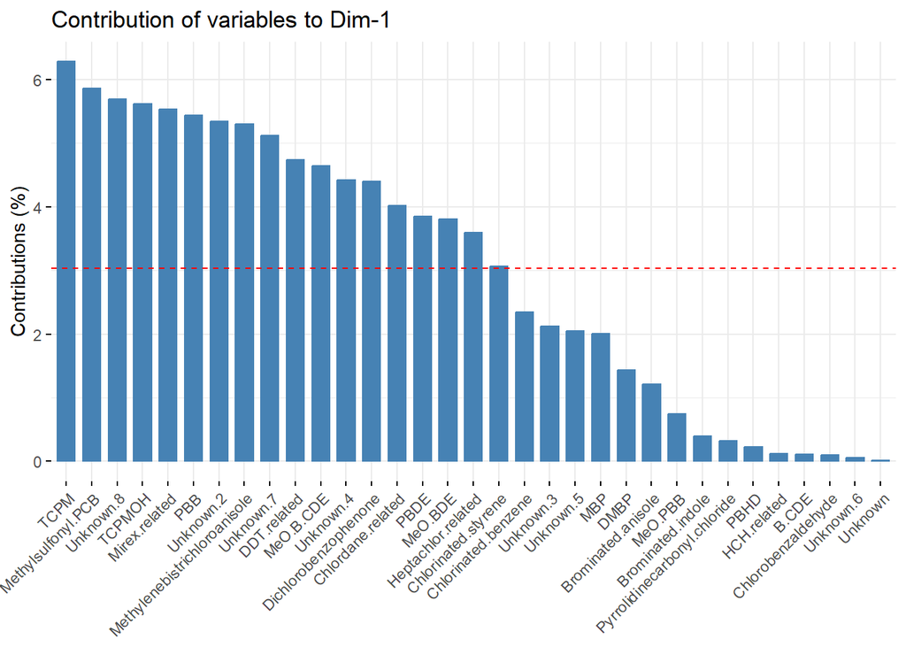

```r
fviz_contrib(dolphin.pca, choice="var", axes = 1 ) #visualizing which variables are important for the analysis
```

```r
#will now remove all the variables under the red line and keep that fall ABOVE the red line

dolphin_up=dolphin[,!(names(dolphin) %in% c("Chlorinated.benzene","Unknown.3","Unknown.5","MBP","DMBP","Brominated.anisole","MeO.PBB","Brominated.indole","Pyrrolidinecarbonyl.chloride","PBHD","HCH.related","B.CDE","Chlorobenzaldehyde","Unknown.6","Unknown"))]

#Will re-run PCA with only the important compounds

dolphin.pca2=prcomp(dolphin_up[,c(-1,-2)], center=TRUE, scale.= TRUE)
summary(dolphin.pca2)#PC1 contributes 70% of the variability in the model(!)
```

```
## Importance of components:
##                           PC1    PC2     PC3     PC4    PC5     PC6     PC7
## Standard deviation     3.6209 1.3564 1.04631 0.88700 0.7742 0.46196 0.38245
## Proportion of Variance 0.7284 0.1022 0.06082 0.04371 0.0333 0.01186 0.00813
## Cumulative Proportion  0.7284 0.8306 0.89143 0.93513 0.9684 0.98029 0.98841
##                           PC8     PC9    PC10    PC11    PC12    PC13      PC14
## Standard deviation     0.2846 0.24110 0.17525 0.16922 0.08722 0.04942 7.836e-17
## Proportion of Variance 0.0045 0.00323 0.00171 0.00159 0.00042 0.00014 0.000e+00
## Cumulative Proportion  0.9929 0.99614 0.99785 0.99944 0.99986 1.00000 1.000e+00
```